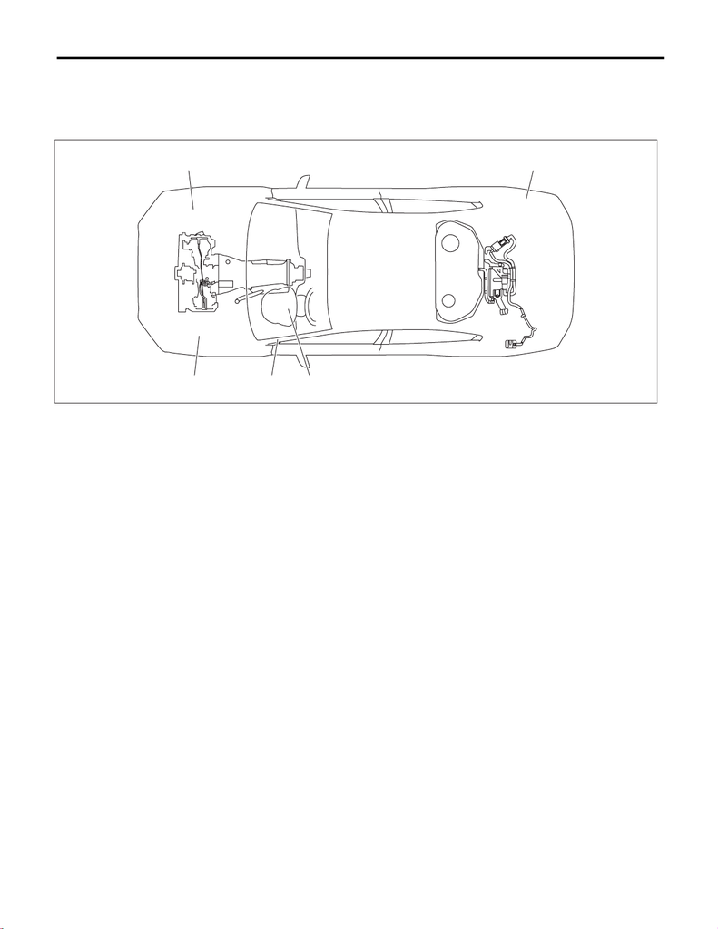

EN(w/o STI)(diag)-9

Electrical Component Location

ENGINE (DIAGNOSTICS)

4. Electrical Component Location

A: LOCATION

1. CONTROL MODULE

(1) Engine control module (ECM) (3) Delivery mode fuse (5) Fuel pump CM

(2) Malfunction indicator light (4) Data link connector

EN-10824

(4) (2)(3)

(1) (5)

[figure not shown]

EN(w/o STI)(diag)-10

Electrical Component Location

ENGINE (DIAGNOSTICS)

EN-10781

(1)

CHECK

ENGINE

(2)

CHECK

ENGINE

EN-10831

EN-10210

(3)

(4)

EN-10211

EN-10971

(5)

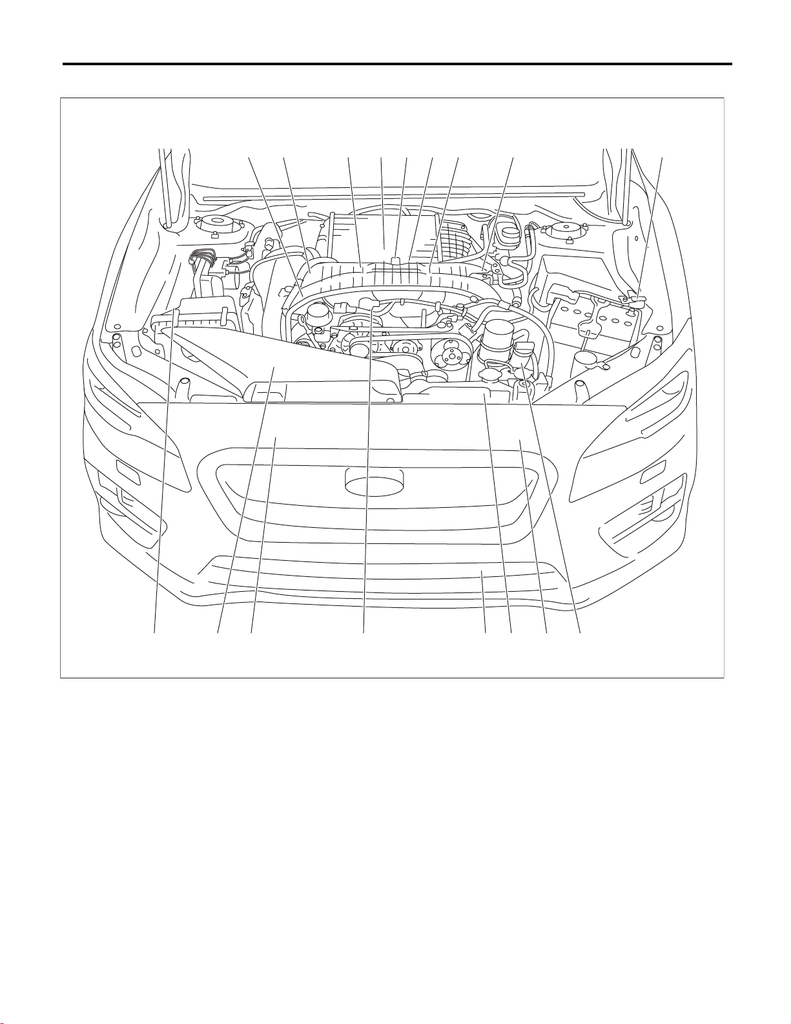

EN(w/o STI)(diag)-11

Electrical Component Location

ENGINE (DIAGNOSTICS)

2. SENSOR

(1) Electronic throttle control (6) Knock sensor LH (11) Engine coolant temperature sen-

sor

(2) Manifold absolute pressure and

intake air temperature sensor

(7) Intake camshaft position sensor (12) Mass air flow and intake air tem-

perature sensor

(3) Tumble generator valve ASSY

(with built-in sensor)

(8) Exhaust camshaft position sensor (13) Fuel pressure sensor

(4) Crankshaft position sensor (9) Engine oil temperature sensor (14) Ambient sensor

(5) Knock sensor RH (10) Battery sensor

EN-10815

(3)

(14) (7)(8)

(4) (6)(2)(13) (3)

(11) (9)(7)

(10)(1)(5)

(12) (8)

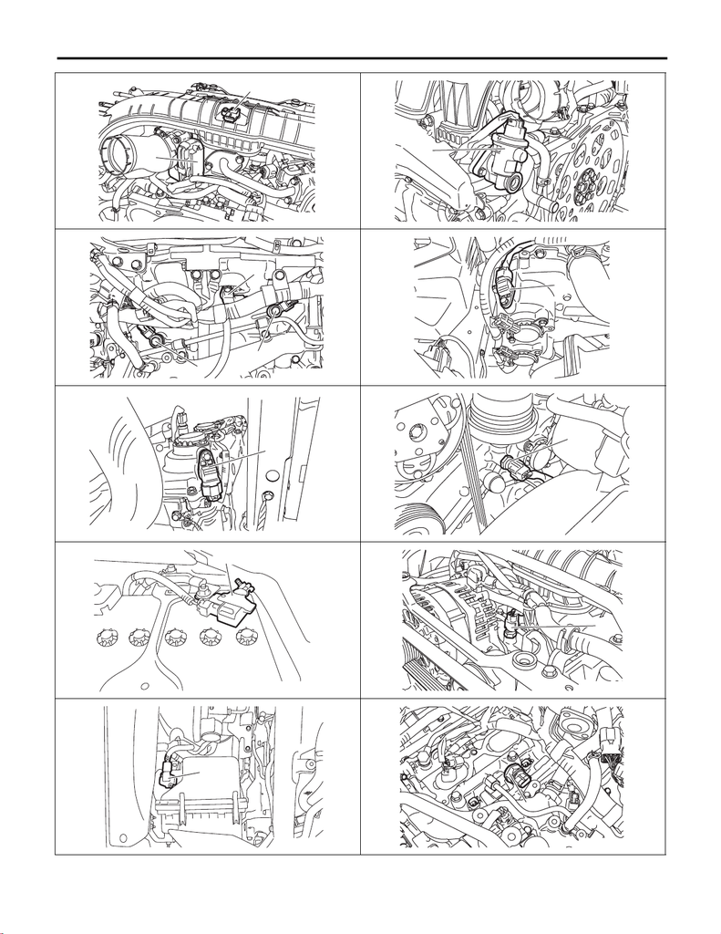

EN(w/o STI)(diag)-12

Electrical Component Location

ENGINE (DIAGNOSTICS)

(2)

(1)

EN-09710

(3)

EN-09711

(4)

(5)

(6)

EN-09712 EN-09025

(7)

EN-09713

(8)

EN-10214

(9)

EN-10775

(10)

(11)

EN-09714

EN-10830

(12)

(13)

EN-09716

[figure not shown]

EN(w/o STI)(diag)-13

Electrical Component Location

ENGINE (DIAGNOSTICS)

(1) Front oxygen (A/F) sensor (3) Rear oxygen sensor (4) Rear catalytic converter

(2) Front catalytic converter

EN-10886

(14)

EN-09717

(3)

(2)

(1)

(4)

[figure not shown]

EN(w/o STI)(diag)-14

Electrical Component Location

ENGINE (DIAGNOSTICS)

(1) Leak check valve ASSY (with

built-in pressure sensor)

(2) Fuel level sensor (3) Fuel sub level sensor

EN-10825

(1)

(3)

(2)

EN-10882

(1)

EN-10473

(2)

EN-08790

(3)

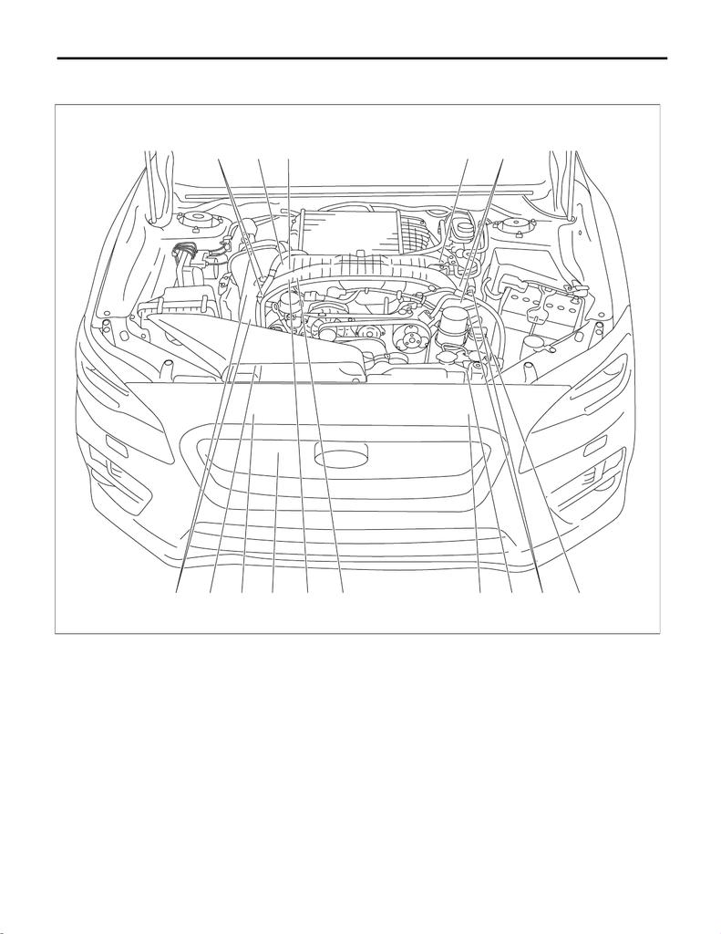

EN(w/o STI)(diag)-15

Electrical Component Location

ENGINE (DIAGNOSTICS)

3. SOLENOID VALVE, ACTUATOR, EMISSION CONTROL SYSTEM PARTS AND IGNITION

SYSTEM PARTS

(1) Wastegate control solenoid valve (5) Purge control solenoid valve 2 (9) High-pressure fuel pump

(2) Ignition coil (6) Intake oil control solenoid (10) Fuel injector

(3) Tumble generator valve ASSY (7) Exhaust oil control solenoid

(4) Purge control solenoid valve 1 (8) EGR control valve

EN-10817

(3) (3)(10)

(4)(5) (6)(7)(6) (2)(1)

(10)(8)

(2) (7) (9)

[figure not shown]

EN(w/o STI)(diag)-16

Electrical Component Location

ENGINE (DIAGNOSTICS)

(1)

EN-09719

(2)

EN-09720

(3)

EN-09711

(5)

(4)

EN-09721

EN-09722

(6)

EN-09030

(7)

(8)

EN-09723

(9)

EN-09724

(10)

EN-09725

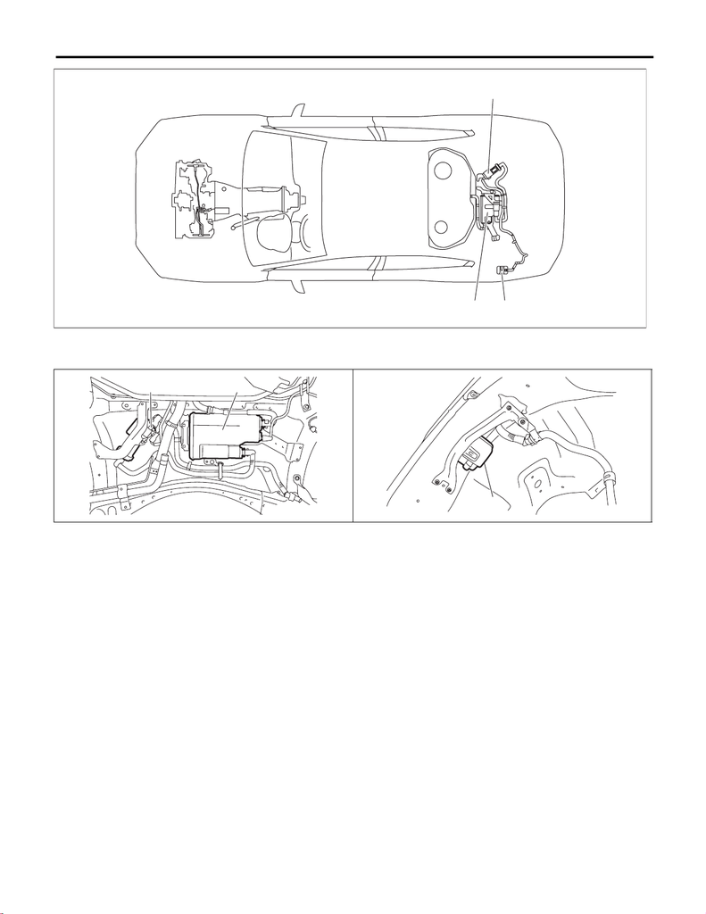

EN(w/o STI)(diag)-17

Electrical Component Location

ENGINE (DIAGNOSTICS)

(1) Leak check valve ASSY (2) Canister (3) Drain filter

EN-10826

(2)

(1)

(3)

EN-10786

(1)

(2)

EN-10783

(3)

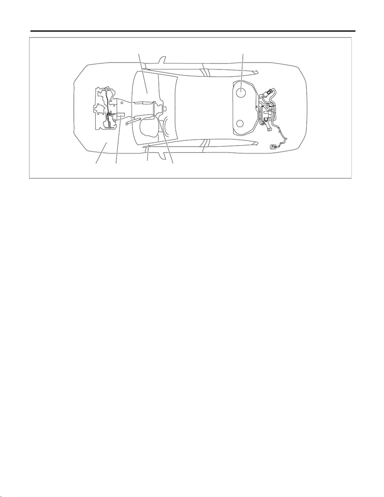

EN(w/o STI)(diag)-18

Electrical Component Location

ENGINE (DIAGNOSTICS)

(1) Starter (7) Main relay (12) Starter relay

(2) Fuel pump (8) IG relay (13) Starter cut relay (model with push

button start)

(3) Radiator main fan relay 1 (9) Fuel pump relay (14) IG relay 1 (push button start)

(model with push button start)

(4) Radiator main fan relay 2 (10) A/F, oxygen sensor relay (15) Starter relay (push button start)

(model with push button start)

(5) Radiator sub fan relay (11) Electronic throttle control relay (16) Push button ignition switch (model

with push button start)

(6) Fuel injector relay

EN-10827

(7)(8)(9)

(1)

(10)(11)(12)

(13)(14)(15)

(16)(3)(4)(5)(6)

(2)

[figure not shown]

EN(w/o STI)(diag)-19

Electrical Component Location

ENGINE (DIAGNOSTICS)

4. TRANSMISSION

(1) Inhibitor switch (CVT model) (2) Neutral position switch (MT

model)

(1)

EN-09727 EN-10186

(2)

EN-10829

(6)(3)

(4)

(5)

EN-10828

(7)

(8)

(9)

EN-10224

(10)

(11)

(12)

(13)

(14)

(15)

EN-10226

(16)

EN-07518

(1)

EN-10889

(2)